# Map of Bangladesh from shape file

Ferdausur Rahman

12/21/2021

# **Hi!**

### I am Ferdausur Rahman

I tried to plot **the map of Bangladesh** from **.shp** file. The file can be found on Google by searching with **Bangladesh.shp or Bangladesh shape file**. I took the file from **[DIVA-GIS](https://www.diva-gis.org/gdata)** as **.zip** file and extracted in my working directory.

## Setting Working Directory

```r
wd<- getwd()
```

## Load libraries

**sf** package is to read shape file and **ggplot2** to plot

```r
library(sf)
```

```r
library(ggplot2)
```

## Reading data

The shape file could also be read with **st.read()** from **sf** package and **readOGR()** from **rgdal** package.

adm0 contains information on the country, country name.

```r
adm0<- read_sf(paste(wd, "BGD_adm/BGD_adm0.shp", sep= "/"))
head(adm0)
```

```
## Simple feature collection with 1 feature and 70 fields
## Geometry type: MULTIPOLYGON
## Dimension:     XY
## Bounding box:  xmin: 88.01057 ymin: 20.74111 xmax: 92.67366 ymax: 26.6344
## Geodetic CRS:  WGS 84
## # A tibble: 1 x 71
##    ID_0 ISO   NAME_0     OBJECTID_1 ISO3  NAME_ENGLI NAME_ISO NAME_FAO NAME_LOCAL
##   <dbl> <chr> <chr>           <dbl> <chr> <chr>      <chr>    <chr>    <chr>
## 1    20 BGD   Bangladesh         23 BGD   Bangladesh BANGLAD~ Banglad~ Bangladesh
## # ... with 62 more variables: NAME_OBSOL <chr>, NAME_VARIA <chr>,
## #   NAME_NONLA <chr>, NAME_FRENC <chr>, NAME_SPANI <chr>, NAME_RUSSI <chr>,
## #   NAME_ARABI <chr>, NAME_CHINE <chr>, WASPARTOF <chr>, CONTAINS <chr>,
## #   SOVEREIGN <chr>, ISO2 <chr>, WWW <chr>, FIPS <chr>, ISON <dbl>,
## #   VALIDFR <chr>, VALIDTO <chr>, POP2000 <dbl>, SQKM <dbl>, POPSQKM <dbl>,
## #   UNREGION1 <chr>, UNREGION2 <chr>, DEVELOPING <dbl>, CIS <dbl>,
## #   Transition <dbl>, OECD <dbl>, WBREGION <chr>, WBINCOME <chr>, ...
```

adm1 contains information on division.

```r
adm1<- read_sf(paste(wd, "BGD_adm/BGD_adm1.shp", sep= "/"))
head(adm1)
```

```
## Simple feature collection with 6 features and 9 fields
## Geometry type: MULTIPOLYGON
## Dimension:     XY
## Bounding box:  xmin: 88.01057 ymin: 20.74111 xmax: 92.67366 ymax: 26.6344
## Geodetic CRS:  WGS 84
## # A tibble: 6 x 10
##    ID_0 ISO   NAME_0      ID_1 NAME_1     TYPE_1 ENGTYPE_1 NL_NAME_1 VARNAME_1
##   <dbl> <chr> <chr>      <dbl> <chr>      <chr>  <chr>     <chr>     <chr>
## 1    20 BGD   Bangladesh     1 Barisal    Bibhag Division  <NA>      Bakerganj
## 2    20 BGD   Bangladesh     2 Chittagong Bibhag Division  <NA>      Chattagram~
## 3    20 BGD   Bangladesh     3 Dhaka      Bibhag Division  <NA>      Daca|Dacca
## 4    20 BGD   Bangladesh     4 Khulna     Bibhag Division  <NA>      <NA>
## 5    20 BGD   Bangladesh     5 Rajshahi   Bibhag Division  <NA>      <NA>
## 6    20 BGD   Bangladesh     6 Rangpur    Bibhag Division  <NA>      <NA>
## # ... with 1 more variable: geometry <MULTIPOLYGON [°]>
```

adm2 in on districts of Bangladesh.

```r
adm2<- read_sf(paste(wd, "BGD_adm/BGD_adm2.shp", sep= "/"))
head(adm2)
```

```
## Simple feature collection with 6 features and 11 fields
## Geometry type: MULTIPOLYGON
## Dimension:     XY
## Bounding box:  xmin: 89.86407 ymin: 21.73779 xmax: 91.00111 ymax: 23.07116
## Geodetic CRS:  WGS 84
## # A tibble: 6 x 12
##    ID_0 ISO   NAME_0      ID_1 NAME_1   ID_2 NAME_2     TYPE_2 ENGTYPE_2 NL_NAME_2
##   <dbl> <chr> <chr>      <dbl> <chr>   <dbl> <chr>      <chr>  <chr>     <chr>
## 1    20 BGD   Bangladesh     1 Barisal     1 Barisal    Zila   District  <NA>
## 2    20 BGD   Bangladesh     1 Barisal     2 Bhola      Zila   District  <NA>
## 3    20 BGD   Bangladesh     1 Barisal     3 Borgona    Zila   District  <NA>
## 4    20 BGD   Bangladesh     1 Barisal     4 Jhalakati  Zila   District  <NA>
## 5    20 BGD   Bangladesh     1 Barisal     5 Patuakhali Zila   District  <NA>
## 6    20 BGD   Bangladesh     1 Barisal     6 Pirojpur   Zila   District  <NA>
## # ... with 2 more variables: VARNAME_2 <chr>, geometry <MULTIPOLYGON [°]>
```

adm3 has previous information and information on upazila.

```r
adm3<- read_sf(paste(wd, "BGD_adm/BGD_adm3.shp", sep= "/"))
head(adm3)
```

```
## Simple feature collection with 6 features and 13 fields
## Geometry type: MULTIPOLYGON
## Dimension:     XY
## Bounding box:  xmin: 90.03049 ymin: 22.45434 xmax: 90.53994 ymax: 23.07116
## Geodetic CRS:  WGS 84
## # A tibble: 6 x 14
##    ID_0 ISO   NAME_0      ID_1 NAME_1   ID_2 NAME_2   ID_3 NAME_3 TYPE_3 ENGTYPE_3
##   <dbl> <chr> <chr>      <dbl> <chr>   <dbl> <chr>   <dbl> <chr>  <chr>  <chr>
## 1    20 BGD   Bangladesh     1 Barisal     1 Barisal     1 Agail~ Upazi~ Sub-dist~
## 2    20 BGD   Bangladesh     1 Barisal     1 Barisal     2 Babug~ Upazi~ Sub-dist~
## 3    20 BGD   Bangladesh     1 Barisal     1 Barisal     3 Baker~ Upazi~ Sub-dist~
## 4    20 BGD   Bangladesh     1 Barisal     1 Barisal     4 Banar~ Upazi~ Sub-dist~
## 5    20 BGD   Bangladesh     1 Barisal     1 Barisal     5 Baris~ Upazi~ Sub-dist~
## 6    20 BGD   Bangladesh     1 Barisal     1 Barisal     6 Gaurn~ Upazi~ Sub-dist~
## # ... with 3 more variables: NL_NAME_3 <chr>, VARNAME_3 <chr>,
## #   geometry <MULTIPOLYGON [°]>
```

## Plotting the map

If the shape data was read by **readOGR()**, map could be also be plotted by getting latitude, longitude from **tidy()** of **broom** package and then calling **geom_polygon()** on the file.

### A solid map of Bangladesh as adm0 only have country information.

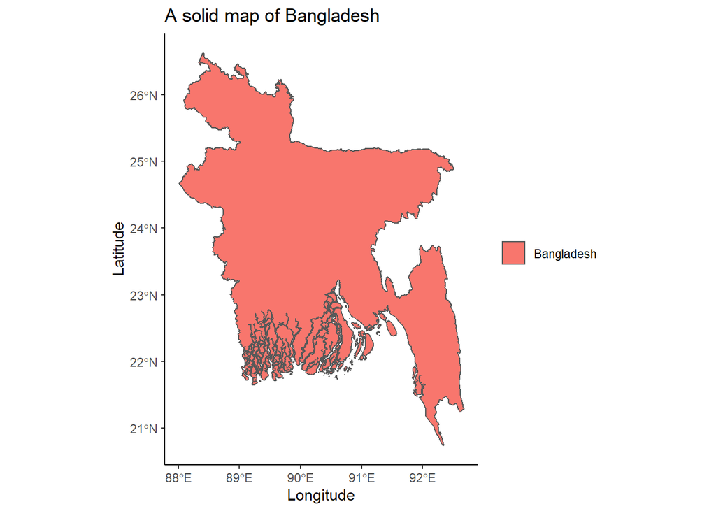

```r
map0<- ggplot(adm0)+
        geom_sf(aes(fill= NAME_0))+
        labs(title = "A solid map of Bangladesh",
             x= "Longitude", y= "Latitude")+
        theme_classic()+
        theme(legend.title = element_blank())

map0
```

### adm1 has divisional distribution on column NAME_1.

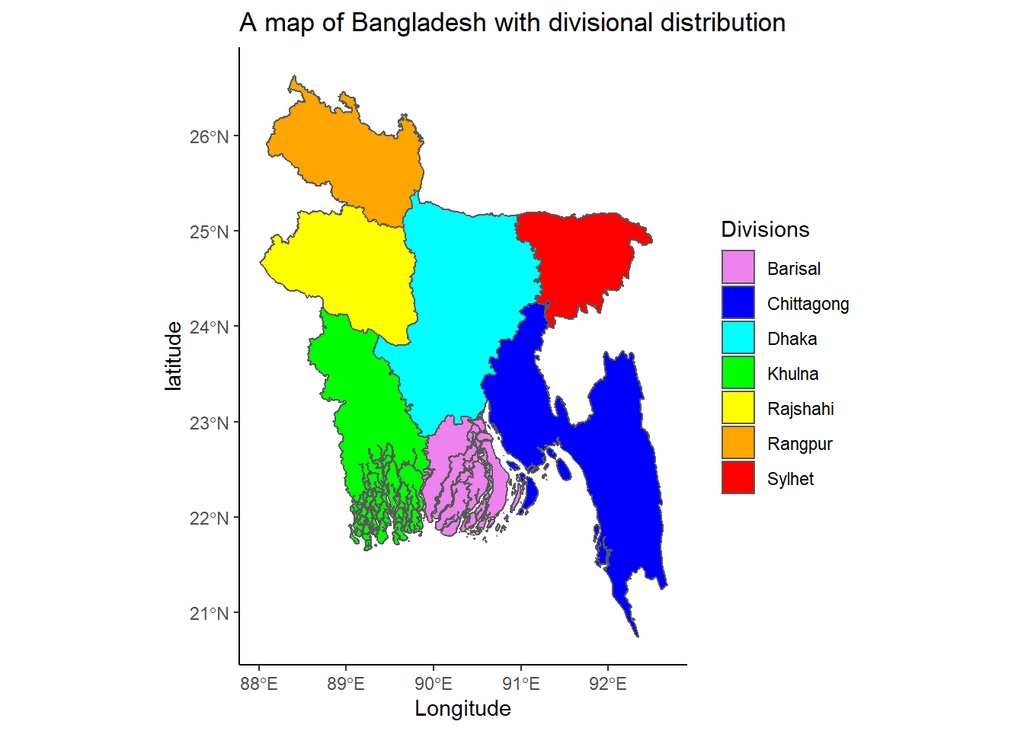

```r
map1<- ggplot(adm1)+
        geom_sf(aes(fill= NAME_1))+
        labs(title= "A map of Bangladesh with divisional distribution",
             x= "Longitude", y= "latitude")+
        scale_fill_manual("Divisions",
                          values= c("violet", "blue", "cyan", "green",
                                    "yellow", "orange", "red"))+
        theme_classic()
map1
```

### A map of Bangladesh on districts

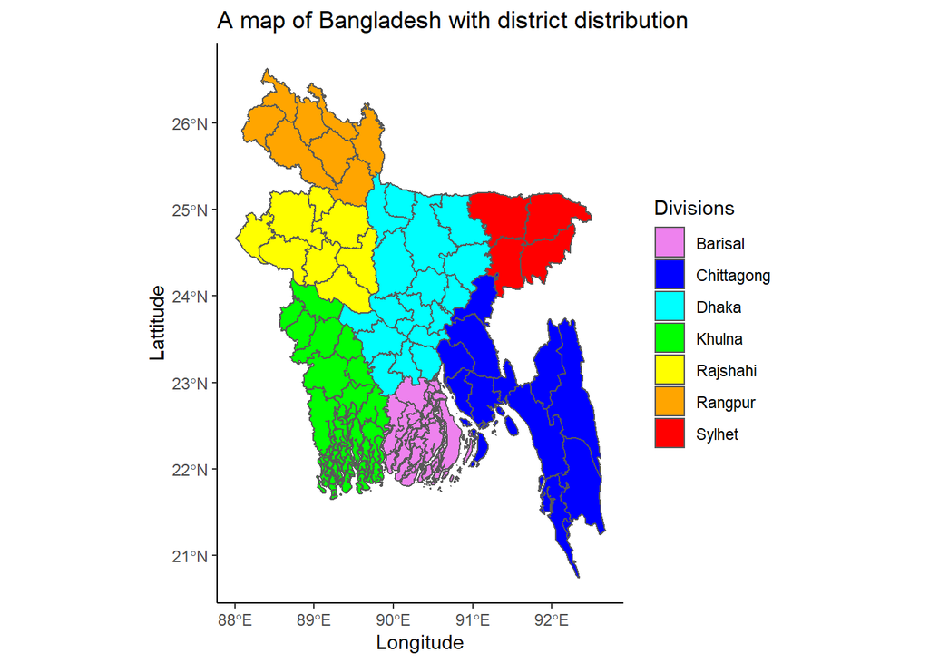

```r
map2 <- ggplot(adm2)+
        geom_sf(aes(fill=NAME_1))+
        labs(title="A map of Bangladesh with district distribution",
             x="Longitude",y="Lattitude")+
        theme_classic()+
        scale_fill_manual("Divisions",
                          values= c("violet", "blue", "cyan", "green",
                                    "yellow", "orange", "red"))
map2
```

### A map of Bangladesh on Upazila

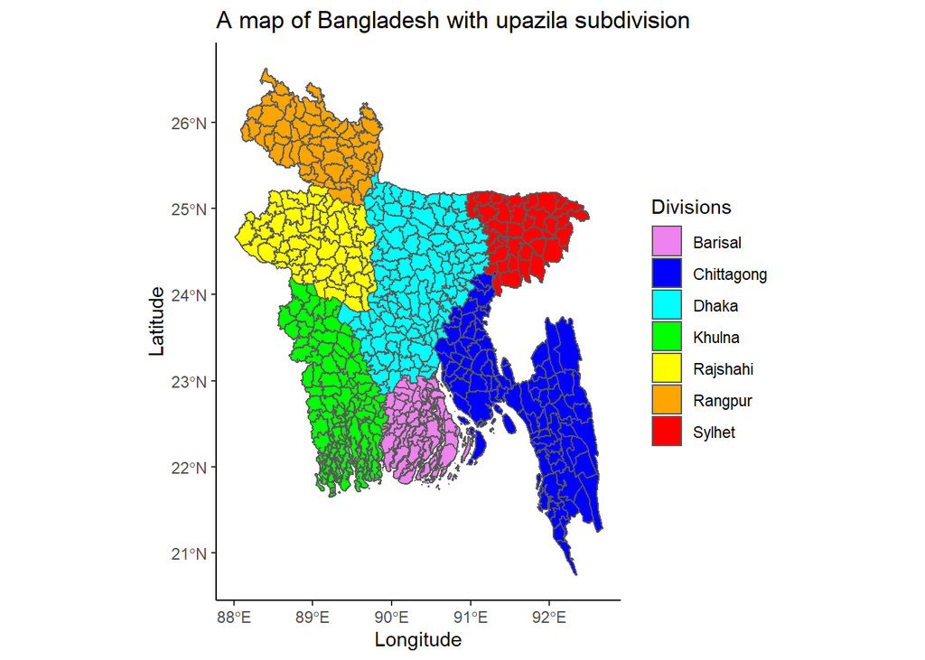

```r
map3<- ggplot(adm3)+
        geom_sf(aes(fill= NAME_1))+
        labs(title= "A map of Bangladesh with upazila subdivision",
             x= "Longitude", y= "Latitude")+
        theme_classic()+
        scale_fill_manual("Divisions",
                          values= c("violet", "blue", "cyan", "green",
                                    "yellow", "orange", "red"))
map3
```

## Adding labels on the map

Labels can be added both as text and labels.

- Text and label can be added with **geom_text()** and **geom_label()** respectively. However, they need x and y coordinates along with the label/ texts.  
  Approximate x and y can be taken from plotting the map without label first and then re-plotting with labels and coordinates.

```r
lats<- c(25.800, 24.800, 24.700, 23.600, 23.100, 22.850, 22.500, 21.000)
longs<- c(89.200, 91.600, 89.000, 90.100, 89.400, 91.900, 90.300, 90.800)

label_name<- c("Rangpur", "Sylhet", "Rajshahi", "Dhaka",
         "Khulna", "Chittagong", "Barishal", "Bay of Bengal")

lab_df<- data.frame(label_name, longs, lats)
```

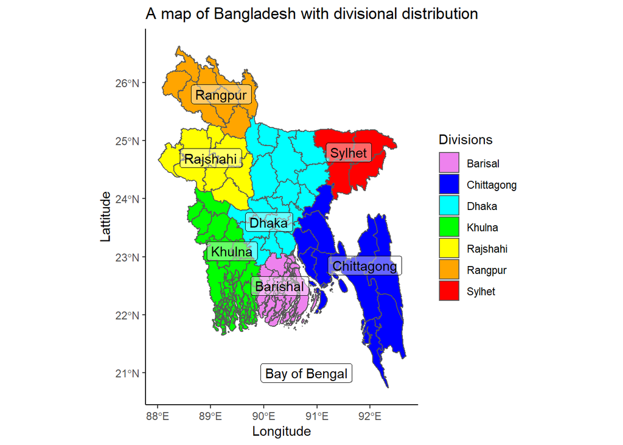

```r
map4 <- ggplot(adm2)+
        geom_sf(aes(fill=NAME_1))+
        labs(title="A map of Bangladesh with divisional distribution",
             x="Longitude",y="Lattitude")+
        theme_classic()+
        geom_label(data = lab_df,
                   aes(x= longs, y= lats, label= label_name),
                   alpha= 0.4)+
        scale_fill_manual("Divisions",
                          values= c("violet", "blue", "cyan", "green",
                                    "yellow", "orange", "red"))
map4
```

- Text and labels can be also added with **geom_sf_text()** and **geom_sf_label()**. They do not require x and y coordinates for adding label/text.

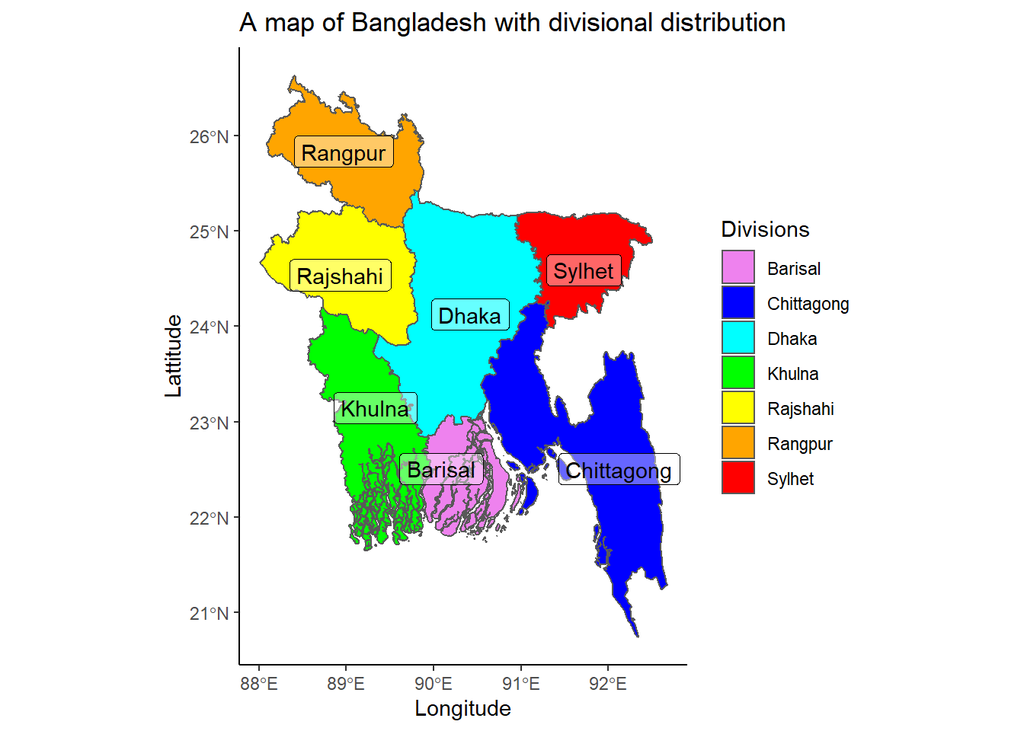

```r
map5 <- ggplot(adm1)+
        geom_sf(aes(fill=NAME_1))+
        labs(title="A map of Bangladesh with divisional distribution",
             x="Longitude",y="Lattitude")+
        theme_classic()+
        geom_sf_label(aes(label= NAME_1), alpha= 0.4)+
        scale_fill_manual("Divisions",
                          values= c("violet", "blue", "cyan", "green",
                                    "yellow", "orange", "red"))

map5
```

## Making fill according to a given variable/ column/ information

Population of Bangladesh is taken from [Divisions of Bangladesh](https://en.wikipedia.org/wiki/Divisions_of_Bangladesh) Wikipedia page is added to the data

```r
adm1$population<- c(8325666, 29145000, 36433505, 15687759,
                      18485858, 15787758, 9807000)
```

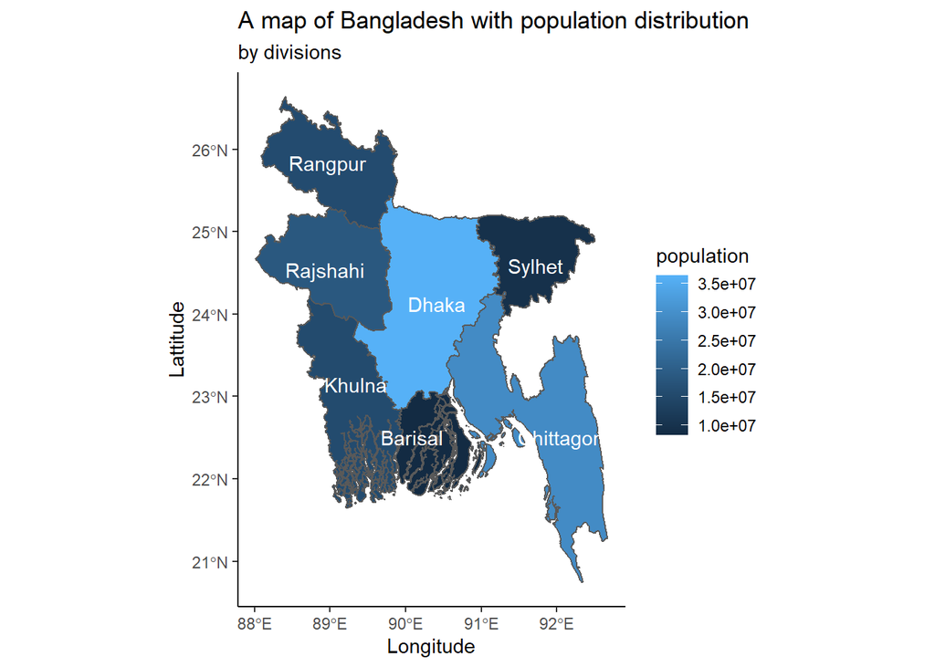

```r
map6 <- ggplot(adm1)+
        geom_sf(aes(fill=population))+
        labs(title="A map of Bangladesh with population distribution",
             subtitle = "by divisions",
             x="Longitude",y="Lattitude")+
        theme_classic()+
        geom_sf_text(aes(label= NAME_1), color= "white")

map6
```

### Thank you for reading. Hope this helps you.